# Prediction of Student Performance in Secondary Education

### Introduction

In this group assignment for WQD7004: Programming for Data Science, the scope is to use R Programming to create both a classification model as well as a regression model using a single dataset for prediction purposes. After careful consideration and discussion, the chosen dataset is determined to be Student Data collected by Cortez and Silva (2008) in their research.

For context, the research conducted by Cortez and Silva (2008) was to assess the educational level of the Portuguese population from two different schools. This was presented as a concern as statistics have shown that Portugal has one of the highest failure rates in Europe despite their continuous improvements in the last decade. In 2006, the early school leaving rate in Portugal was 40% for those aged 18-24 years old, while the European Union average was only 15% (Eurostat, 2007). The two subjects most important are Mathematics and Portuguese as they are core classes that provide students with the fundamental information for success in other school subjects, such as Chemistry and History.

Modeling student performance has consequently always been an important tool for both educators, students, and researchers alike. It can help to further research in the domain of factors that affect student achievement. Thus, the researchers from previous study addressed the prediction of secondary student grades by using past school performance, demographic, social, and other school related data. They then tested out three different data mining goals (binary classification, five level classification, and regression) and four data mining methods (decision trees, random forests, neural networks, and support vector machines).

In concluding the previous study, the past researchers have noted that the best predictive accuracy of the final grade can be achieved if past performance grades are evaluated and that predictive performance decreases when each subsequent past performance is not used. However, the researchers have also postulated that the effects of other variables, such as number of school absences, parent’s job and education, and alcohol consumption, also influence the prediction of a student’s final grade, just not as much as past performance.

For this group assignment, the goal is to improve the performance of the prediction. We focused only on the Portuguese language dataset as the number of record is higher compared to the Mathematics dataset.

### Problem Statement

Education plays a vital role in the growth and development of a country. Therefore, it is crucial to predict student performance so that education practitioners can formulate plans to improve the education system. Furthermore, it is also essential to identify the factors that affects the student performance in education. Hence, we aimed to explore the correlation between student grades, demographic, social and school related features, and the student’s final grade. We also develop the regression and classification models to predict student performance.

### Research Questions

1. What are the factors that highly impact to the student performance?
2. How to design prediction models to predict student performance?
3. Which model is the best to predict student performance?

### Research Objectives

1. To identify the factors that highly correlated with the student performance
2. To create the regression and classification models to predict student performance
3. To evaluate the performance of the models

### Dataset

[Student Performance Data Set](https://archive.ics.uci.edu/ml/datasets/student+performance)

This dataset consists of student performance in secondary education of two Portuguese schools in year 2005 - 2006. It was collected through school reports and questionnaires.

In this project, we are interested in the student performance in the Portuguese subject. It consists of 649 observations and 33 variables.

### Metadata

| Variable | Description |
| --- | --- |
| school | student’s school (binary: ‘GP’ - Gabriel Pereira or ‘MS’ - Mousinho da Silveira) |
| sex | student’s sex (binary: ‘F’ - female or ‘M’ - male) |
| age | student’s age (numeric: from 15 to 22) |
| address | student’s home address type (binary: ‘U’ - urban or ‘R’ - rural) |
| famsize | family size (binary: ‘LE3’ - less or equal to 3 or ‘GT3’ - greater than 3) |
| Pstatus | parent’s cohabitation status (binary: ‘T’ - living together or ‘A’ - apart) |
| Medu | mother’s education (numeric: 0 - none, 1 - primary education (4th grade), 2 - 5th to 9th grade, 3 - secondary education or 4 - higher education) |
| Fedu | father’s education (numeric: 0 - none, 1 - primary education (4th grade), 2 - 5th to 9th grade, 3 - secondary education or 4 - higher education) |
| Mjob | mother’s job (nominal: ‘teacher’, ‘health’ care related, civil ‘services’ (e.g. administrative or police), ‘at_home’ or ‘other’) |
| Fjob | father’s job (nominal: ‘teacher’, ‘health’ care related, civil ‘services’ (e.g. administrative or police), ‘at_home’ or ‘other’) |
| reason | reason to choose this school (nominal: close to ‘home’, school ‘reputation’, ‘course’ preference or ‘other’) |
| guardian | student’s guardian (nominal: ‘mother’, ‘father’ or ‘other’) |
| traveltime | home to school travel time (numeric: 1 - <15 min., 2 - 15 to 30 min., 3 - 30 min. to 1 hour, or 4 - >1 hour) |
| studytime | weekly study time (numeric: 1 - <2 hours, 2 - 2 to 5 hours, 3 - 5 to 10 hours, or 4 - >10 hours) |
| failures | number of past class failures (numeric: n if 0<=n<=2, else 3) |
| schoolsup | extra educational support (binary: yes or no) |
| famsup | family educational support (binary: yes or no) |
| paid | extra paid classes within the course subject (Math or Portuguese) (binary: yes or no) |
| activities | extra-curricular activities (binary: yes or no) |
| nursery | attended nursery school (binary: yes or no) |
| higher | wants to take higher education (binary: yes or no) |
| internet | Internet access at home (binary: yes or no) |
| romantic | with a romantic relationship (binary: yes or no) |
| famrel | quality of family relationships (numeric: from 1 - very bad to 5 - excellent) |
| freetime | free time after school (numeric: from 1 - very low to 5 - very high) |
| goout | going out with friends (numeric: from 1 - very low to 5 - very high) |
| Dalc | workday alcohol consumption (numeric: from 1 - very low to 5 - very high) |
| Walc | weekend alcohol consumption (numeric: from 1 - very low to 5 - very high) |
| health | current health status (numeric: from 1 - very bad to 5 - very good) |
| absences | number of school absences (numeric: from 0 to 93) |
| G1 | first period grade (numeric: from 0 to 20) |
| G2 | second period grade (numeric: from 0 to 20) |
| G3 | final grade (numeric: from 0 to 20, output target) |

### References

1. Cortez, P., & Silva, A. M. G. (2008). Using data mining to predict secondary school student performance. In A. Brito and J. Teixeira Eds., Proceedings of 5th FUture BUsiness TEChnology Conference (FUBUTEC 2008) pp. 5-12, Porto, Portugal, April, 2008, EUROSIS, ISBN 978-9077381-39-7.
2. Eurostat. (2007). Early school-leavers. http://epp.eurostat.ec.europa.eu/.

### Imports

```r
library(dplyr)
```

```r
library(ggplot2)
library(caret)
library(reshape)
df <- read.csv("../data/student-por.csv", sep = ";", stringsAsFactors = TRUE)
head(df)
```

```
##   school sex age address famsize Pstatus Medu Fedu     Mjob     Fjob     reason
## 1     GP   F  18       U     GT3       A    4    4  at_home  teacher     course
## 2     GP   F  17       U     GT3       T    1    1  at_home    other     course
## 3     GP   F  15       U     LE3       T    1    1  at_home    other      other
## 4     GP   F  15       U     GT3       T    4    2   health services       home
## 5     GP   F  16       U     GT3       T    3    3    other    other       home
## 6     GP   M  16       U     LE3       T    4    3 services    other reputation
##   guardian traveltime studytime failures schoolsup famsup paid activities
## 1   mother          2         2        0       yes     no   no         no
## 2   father          1         2        0        no    yes   no         no
## 3   mother          1         2        0       yes     no   no         no
## 4   mother          1         3        0        no    yes   no        yes
## 5   father          1         2        0        no    yes   no         no
## 6   mother          1         2        0        no    yes   no        yes
##   nursery higher internet romantic famrel freetime goout Dalc Walc health
## 1     yes    yes       no       no      4        3     4    1    1      3
## 2      no    yes      yes       no      5        3     3    1    1      3
## 3     yes    yes      yes       no      4        3     2    2    3      3
## 4     yes    yes      yes      yes      3        2     2    1    1      5
## 5     yes    yes       no       no      4        3     2    1    2      5
## 6     yes    yes      yes       no      5        4     2    1    2      5
##   absences G1 G2 G3
## 1        4  0 11 11
## 2        2  9 11 11
## 3        6 12 13 12
## 4        0 14 14 14
## 5        0 11 13 13
## 6        6 12 12 13
```

### Preprocessing

```r
str(df)
```

```
## 'data.frame':    649 obs. of  33 variables:
##  $ school    : Factor w/ 2 levels "GP","MS": 1 1 1 1 1 1 1 1 1 1 ...
##  $ sex       : Factor w/ 2 levels "F","M": 1 1 1 1 1 2 2 1 2 2 ...
##  $ age       : int  18 17 15 15 16 16 16 17 15 15 ...
##  $ address   : Factor w/ 2 levels "R","U": 2 2 2 2 2 2 2 2 2 2 ...
##  $ famsize   : Factor w/ 2 levels "GT3","LE3": 1 1 2 1 1 2 2 1 2 1 ...
##  $ Pstatus   : Factor w/ 2 levels "A","T": 1 2 2 2 2 2 2 1 1 2 ...
##  $ Medu      : int  4 1 1 4 3 4 2 4 3 3 ...
##  $ Fedu      : int  4 1 1 2 3 3 2 4 2 4 ...
##  $ Mjob      : Factor w/ 5 levels "at_home","health",..: 1 1 1 2 3 4 3 3 4 3 ...
##  $ Fjob      : Factor w/ 5 levels "at_home","health",..: 5 3 3 4 3 3 3 5 3 3 ...
##  $ reason    : Factor w/ 4 levels "course","home",..: 1 1 3 2 2 4 2 2 2 2 ...
##  $ guardian  : Factor w/ 3 levels "father","mother",..: 2 1 2 2 1 2 2 2 2 2 ...
##  $ traveltime: int  2 1 1 1 1 1 1 2 1 1 ...
##  $ studytime : int  2 2 2 3 2 2 2 2 2 2 ...
```

[output cut: 19 more lines]

```r
summary(df)
```

```
##  school   sex          age        address famsize   Pstatus      Medu
##  GP:423   F:383   Min.   :15.00   R:197   GT3:457   A: 80   Min.   :0.000
##  MS:226   M:266   1st Qu.:16.00   U:452   LE3:192   T:569   1st Qu.:2.000
##                   Median :17.00                             Median :2.000
##                   Mean   :16.74                             Mean   :2.515
##                   3rd Qu.:18.00                             3rd Qu.:4.000
##                   Max.   :22.00                             Max.   :4.000
##       Fedu             Mjob           Fjob            reason      guardian
##  Min.   :0.000   at_home :135   at_home : 42   course    :285   father:153
##  1st Qu.:1.000   health  : 48   health  : 23   home      :149   mother:455
##  Median :2.000   other   :258   other   :367   other     : 72   other : 41
##  Mean   :2.307   services:136   services:181   reputation:143
##  3rd Qu.:3.000   teacher : 72   teacher : 36
##  Max.   :4.000
##    traveltime      studytime        failures      schoolsup famsup     paid
##  Min.   :1.000   Min.   :1.000   Min.   :0.0000   no :581   no :251   no :610
##  1st Qu.:1.000   1st Qu.:1.000   1st Qu.:0.0000   yes: 68   yes:398   yes: 39
##  Median :1.000   Median :2.000   Median :0.0000
##  Mean   :1.569   Mean   :1.931   Mean   :0.2219
##  3rd Qu.:2.000   3rd Qu.:2.000   3rd Qu.:0.0000
##  Max.   :4.000   Max.   :4.000   Max.   :3.0000
##  activities nursery   higher    internet  romantic      famrel
##  no :334    no :128   no : 69   no :151   no :410   Min.   :1.000
##  yes:315    yes:521   yes:580   yes:498   yes:239   1st Qu.:4.000
##                                                     Median :4.000
##                                                     Mean   :3.931
##                                                     3rd Qu.:5.000
##                                                     Max.   :5.000
##     freetime        goout            Dalc            Walc          health
##  Min.   :1.00   Min.   :1.000   Min.   :1.000   Min.   :1.00   Min.   :1.000
##  1st Qu.:3.00   1st Qu.:2.000   1st Qu.:1.000   1st Qu.:1.00   1st Qu.:2.000
##  Median :3.00   Median :3.000   Median :1.000   Median :2.00   Median :4.000
##  Mean   :3.18   Mean   :3.185   Mean   :1.502   Mean   :2.28   Mean   :3.536
##  3rd Qu.:4.00   3rd Qu.:4.000   3rd Qu.:2.000   3rd Qu.:3.00   3rd Qu.:5.000
##  Max.   :5.00   Max.   :5.000   Max.   :5.000   Max.   :5.00   Max.   :5.000
##     absences            G1             G2              G3
##  Min.   : 0.000   Min.   : 0.0   Min.   : 0.00   Min.   : 0.00
##  1st Qu.: 0.000   1st Qu.:10.0   1st Qu.:10.00   1st Qu.:10.00
##  Median : 2.000   Median :11.0   Median :11.00   Median :12.00
##  Mean   : 3.659   Mean   :11.4   Mean   :11.57   Mean   :11.91
##  3rd Qu.: 6.000   3rd Qu.:13.0   3rd Qu.:13.00   3rd Qu.:14.00
##  Max.   :32.000   Max.   :19.0   Max.   :19.00   Max.   :19.00
```

Convert ordinal variables into ordered factors.

```r
df$famsize <- factor(df$famsize, ordered = TRUE, levels = c("LE3", "GT3"))
df$Medu <- factor(df$Medu, ordered = TRUE, levels = 0:4)
df$Fedu <- factor(df$Fedu, ordered = TRUE, levels = 0:4)
df$traveltime <- factor(df$traveltime, ordered = TRUE, levels = 1:4)
df$studytime <- factor(df$studytime, ordered = TRUE, levels = 1:4)
df$failures <- factor(df$failures, ordered = TRUE, levels = 0:4)
df$famrel <- factor(df$famrel, ordered = TRUE, levels = 1:5)
df$freetime <- factor(df$freetime, ordered = TRUE, levels = 1:5)
df$goout <- factor(df$goout, ordered = TRUE, levels = 1:5)
df$Dalc <- factor(df$Dalc, ordered = TRUE, levels = 1:5)
df$Walc <- factor(df$Walc, ordered = TRUE, levels = 1:5)
df$health <- factor(df$health, ordered = TRUE, levels = 1:5)
```

Create label from `G3`.

```r
df$result <- ifelse(df$G3 >= 10, "pass", "fail")
df$result <- as.factor(df$result)
```

### Descriptive Analysis

```r
str(df)
```

```
## 'data.frame':    649 obs. of  34 variables:
##  $ school    : Factor w/ 2 levels "GP","MS": 1 1 1 1 1 1 1 1 1 1 ...
##  $ sex       : Factor w/ 2 levels "F","M": 1 1 1 1 1 2 2 1 2 2 ...
##  $ age       : int  18 17 15 15 16 16 16 17 15 15 ...
##  $ address   : Factor w/ 2 levels "R","U": 2 2 2 2 2 2 2 2 2 2 ...
##  $ famsize   : Ord.factor w/ 2 levels "LE3"<"GT3": 2 2 1 2 2 1 1 2 1 2 ...
##  $ Pstatus   : Factor w/ 2 levels "A","T": 1 2 2 2 2 2 2 1 1 2 ...
##  $ Medu      : Ord.factor w/ 5 levels "0"<"1"<"2"<"3"<..: 5 2 2 5 4 5 3 5 4 4 ...
##  $ Fedu      : Ord.factor w/ 5 levels "0"<"1"<"2"<"3"<..: 5 2 2 3 4 4 3 5 3 5 ...
##  $ Mjob      : Factor w/ 5 levels "at_home","health",..: 1 1 1 2 3 4 3 3 4 3 ...
##  $ Fjob      : Factor w/ 5 levels "at_home","health",..: 5 3 3 4 3 3 3 5 3 3 ...
##  $ reason    : Factor w/ 4 levels "course","home",..: 1 1 3 2 2 4 2 2 2 2 ...
##  $ guardian  : Factor w/ 3 levels "father","mother",..: 2 1 2 2 1 2 2 2 2 2 ...
##  $ traveltime: Ord.factor w/ 4 levels "1"<"2"<"3"<"4": 2 1 1 1 1 1 1 2 1 1 ...
##  $ studytime : Ord.factor w/ 4 levels "1"<"2"<"3"<"4": 2 2 2 3 2 2 2 2 2 2 ...
```

[output cut: 20 more lines]

```r
summary(df)
```

```
##  school   sex          age        address famsize   Pstatus Medu    Fedu
##  GP:423   F:383   Min.   :15.00   R:197   LE3:192   A: 80   0:  6   0:  7
##  MS:226   M:266   1st Qu.:16.00   U:452   GT3:457   T:569   1:143   1:174
##                   Median :17.00                             2:186   2:209
##                   Mean   :16.74                             3:139   3:131
##                   3rd Qu.:18.00                             4:175   4:128
##                   Max.   :22.00
##        Mjob           Fjob            reason      guardian   traveltime
##  at_home :135   at_home : 42   course    :285   father:153   1:366
##  health  : 48   health  : 23   home      :149   mother:455   2:213
##  other   :258   other   :367   other     : 72   other : 41   3: 54
##  services:136   services:181   reputation:143                4: 16
##  teacher : 72   teacher : 36
##
##  studytime failures schoolsup famsup     paid     activities nursery
##  1:212     0:549    no :581   no :251   no :610   no :334    no :128
##  2:305     1: 70    yes: 68   yes:398   yes: 39   yes:315    yes:521
##  3: 97     2: 16
##  4: 35     3: 14
##            4:  0
##
##  higher    internet  romantic  famrel  freetime goout   Dalc    Walc    health
##  no : 69   no :151   no :410   1: 22   1: 45    1: 48   1:451   1:247   1: 90
##  yes:580   yes:498   yes:239   2: 29   2:107    2:145   2:121   2:150   2: 78
##                                3:101   3:251    3:205   3: 43   3:120   3:124
##                                4:317   4:178    4:141   4: 17   4: 87   4:108
##                                5:180   5: 68    5:110   5: 17   5: 45   5:249
##
##     absences            G1             G2              G3         result
##  Min.   : 0.000   Min.   : 0.0   Min.   : 0.00   Min.   : 0.00   fail:100
##  1st Qu.: 0.000   1st Qu.:10.0   1st Qu.:10.00   1st Qu.:10.00   pass:549
##  Median : 2.000   Median :11.0   Median :11.00   Median :12.00
##  Mean   : 3.659   Mean   :11.4   Mean   :11.57   Mean   :11.91
##  3rd Qu.: 6.000   3rd Qu.:13.0   3rd Qu.:13.00   3rd Qu.:14.00
##  Max.   :32.000   Max.   :19.0   Max.   :19.00   Max.   :19.00
```

### Exploratory Data Analysis

#### Univariate

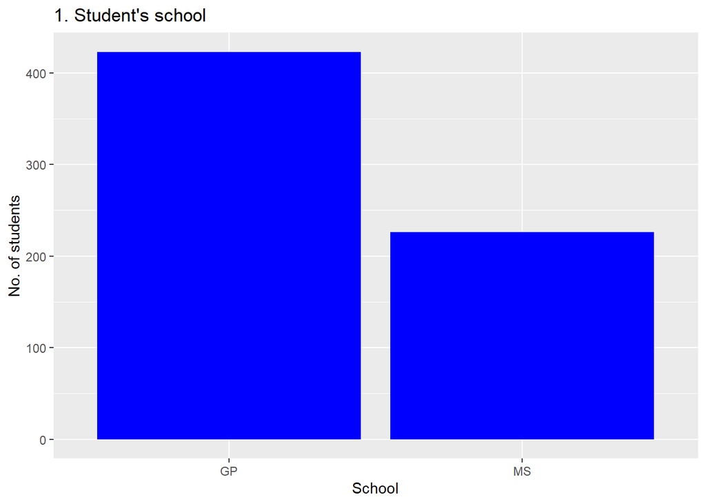

```r
ggplot(df, aes(x = school)) +
  geom_bar(fill = "blue") +
  labs(
    x = "School",
    y = "No. of students",
    title = "1. Student's school"
  )
```

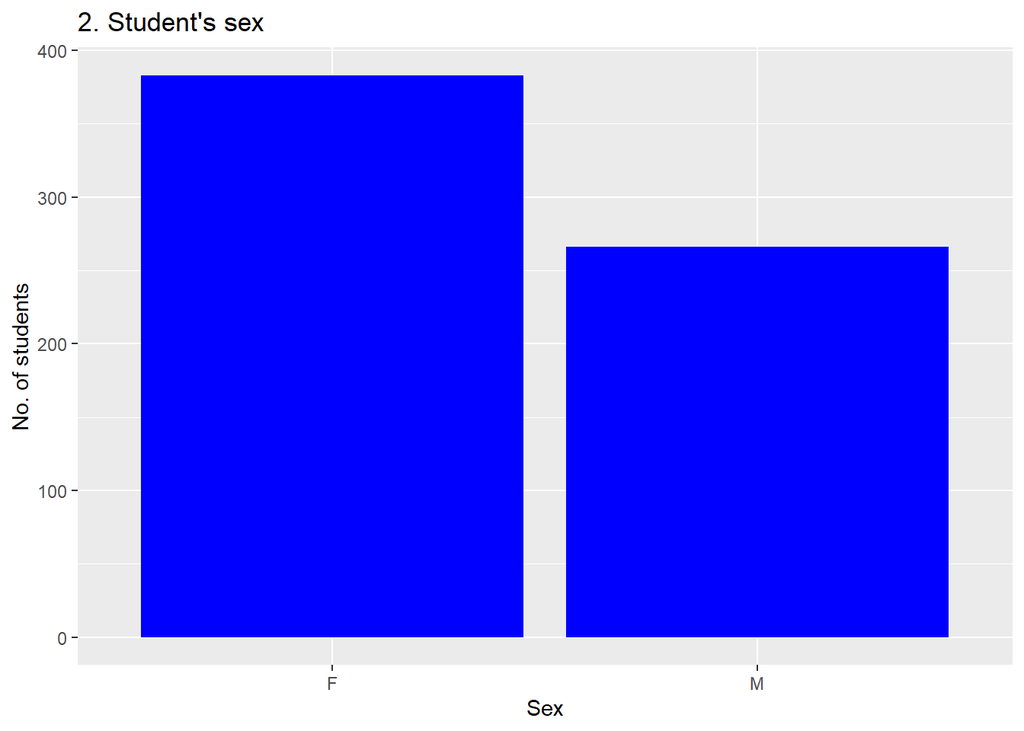

```r
ggplot(df, aes(x = sex)) +
  geom_bar(fill = "blue") +
  labs(
    x = "Sex",
    y = "No. of students",
    title = "2. Student's sex"
  )
```

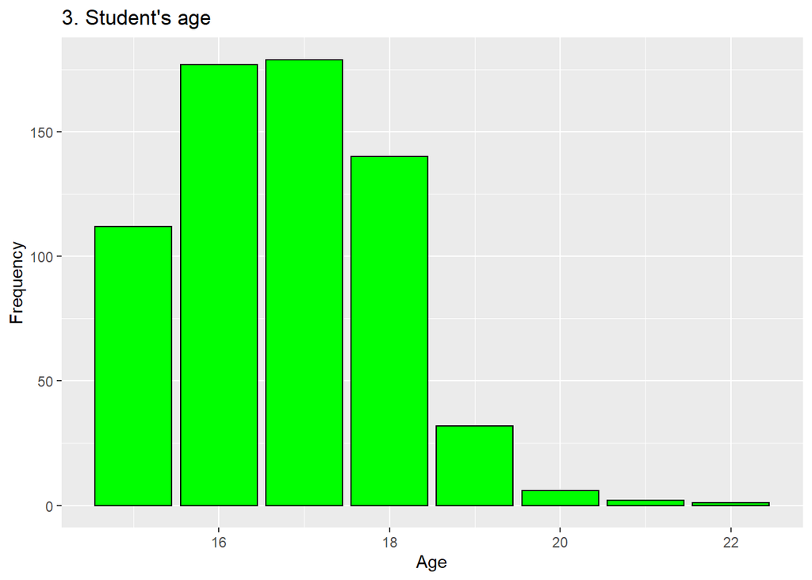

```r
ggplot(df, aes(x = age)) +
  geom_bar(
    fill = "green",
    color = "black"
  ) +
  labs(
    x = "Age",
    y = "Frequency",
    title = "3. Student's age"
  )
```

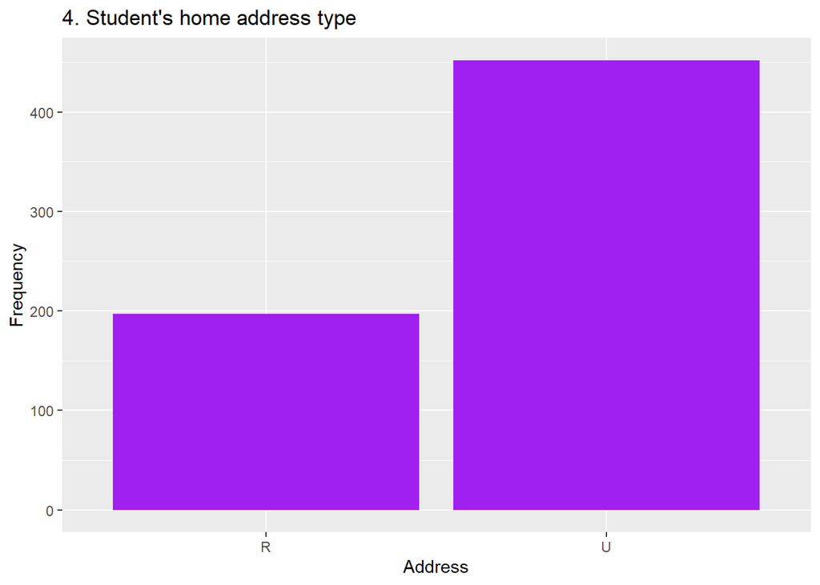

```r
ggplot(df, aes(x = address)) +
  geom_bar(fill = "purple") +
  labs(
    x = "Address",
    y = "Frequency",
    title = "4. Student's home address type"
  )
```

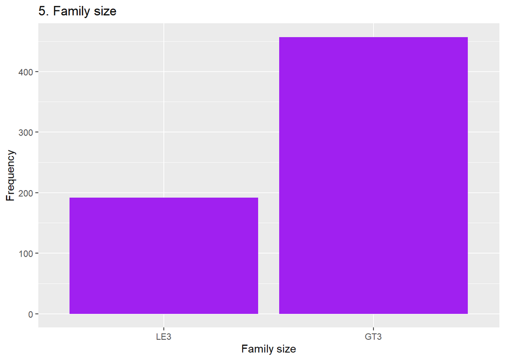

```r
ggplot(df, aes(x = famsize)) +
  geom_bar(fill = "purple") +
  labs(
    x = "Family size",
    y = "Frequency",
    title = "5. Family size "
  )
```

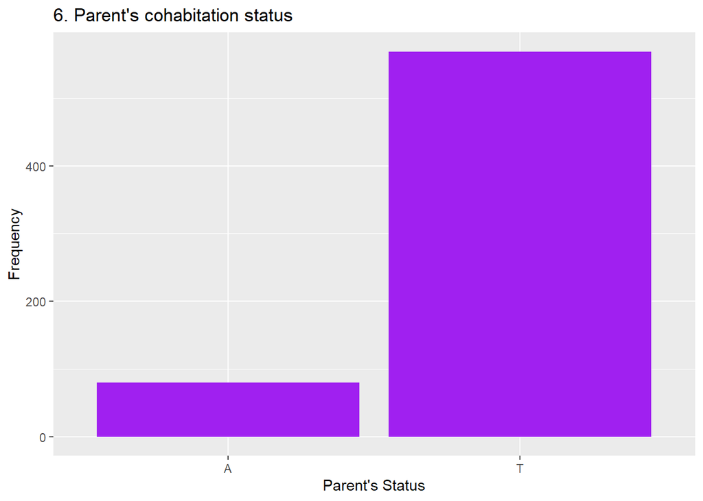

```r
ggplot(df, aes(x = Pstatus)) +
  geom_bar(fill = "purple") +
  labs(
    x = "Parent's Status",
    y = "Frequency",
    title = "6. Parent's cohabitation status "
  )
```

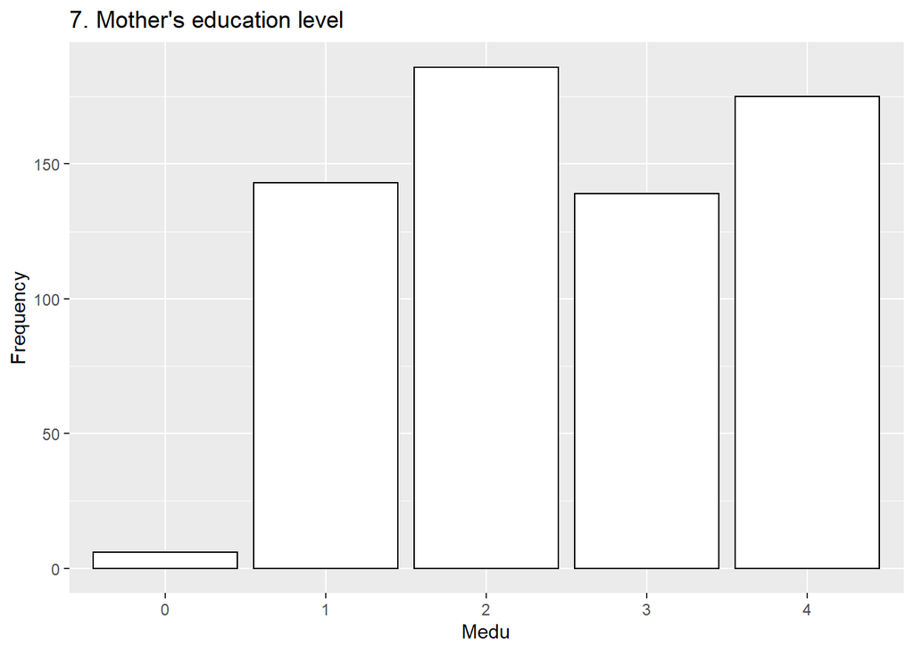

```r
ggplot(df, aes(x = Medu)) +
  geom_bar(
    fill = "white",
    color = "black"
  ) +
  labs(
    x = "Medu",
    y = "Frequency",
    title = "7. Mother's education level"
  )
```

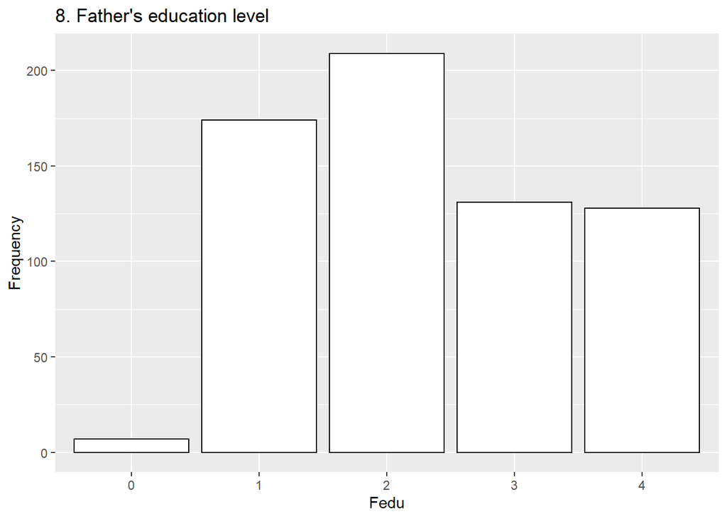

```r
ggplot(df, aes(x = Fedu)) +
  geom_bar(
    fill = "white",
    color = "black"
  ) +
  labs(
    x = "Fedu",
    y = "Frequency",
    title = "8. Father's education level"
  )
```

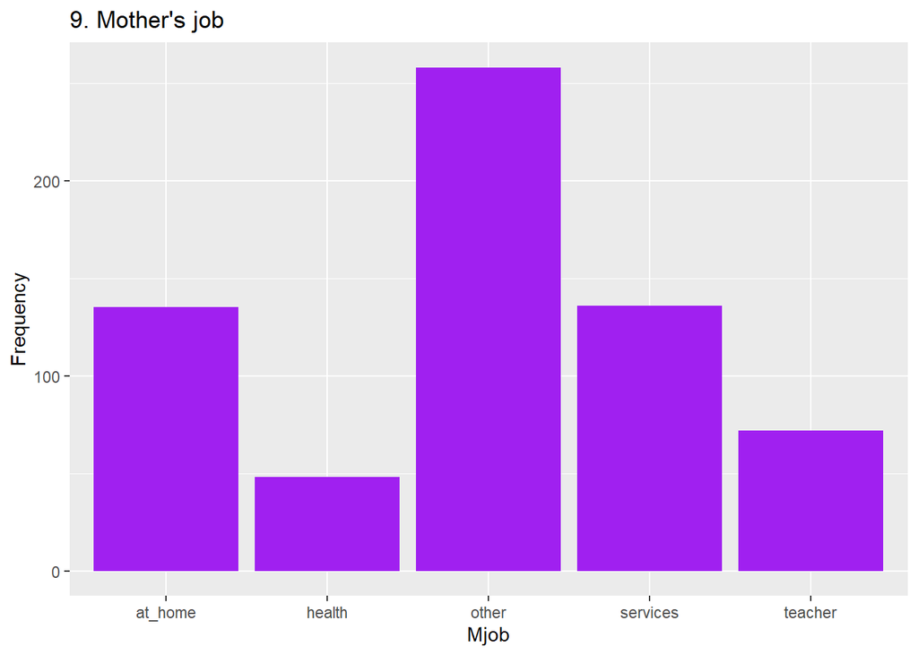

```r
ggplot(df, aes(x = Mjob)) +
  geom_bar(fill = "purple") +
  labs(
    x = "Mjob",
    y = "Frequency",
    title = "9. Mother's job"
  )
```

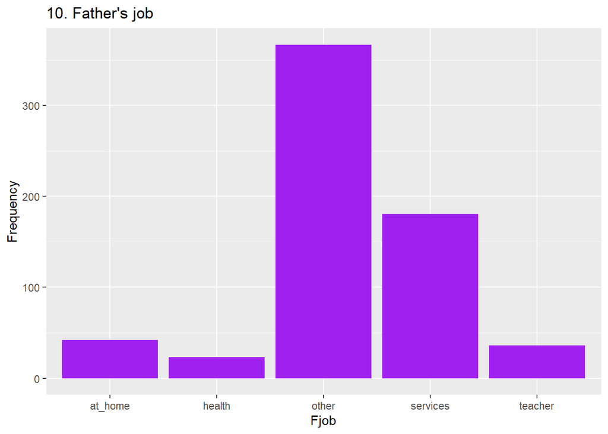

```r
ggplot(df, aes(x = Fjob)) +
  geom_bar(fill = "purple") +
  labs(
    x = "Fjob",
    y = "Frequency",
    title = "10. Father's job"
  )
```

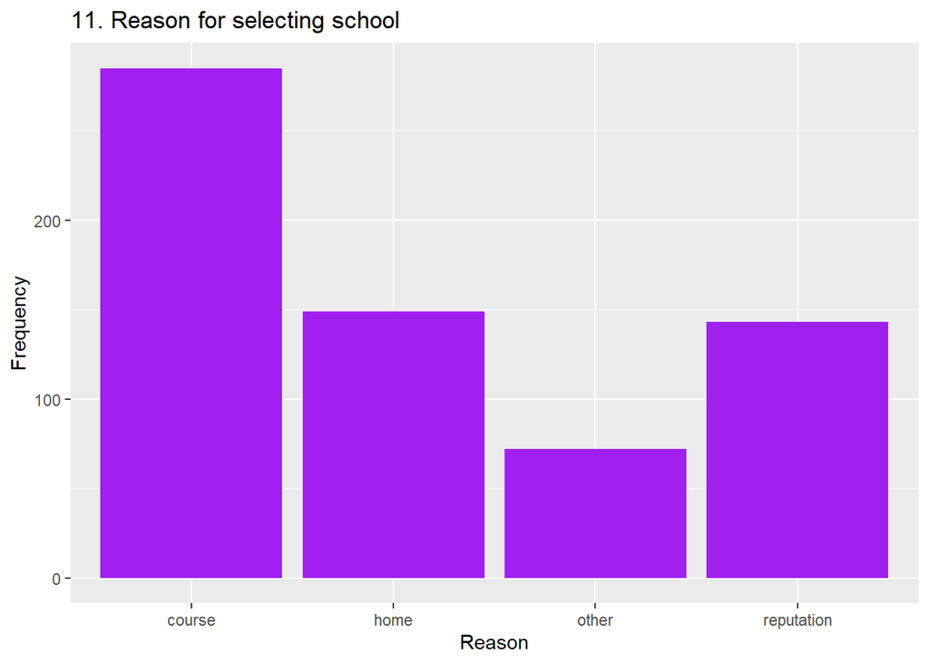

```r
ggplot(df, aes(x = reason)) +
  geom_bar(fill = "purple") +
  labs(
    x = "Reason",
    y = "Frequency",
    title = "11. Reason for selecting school"
  )
```

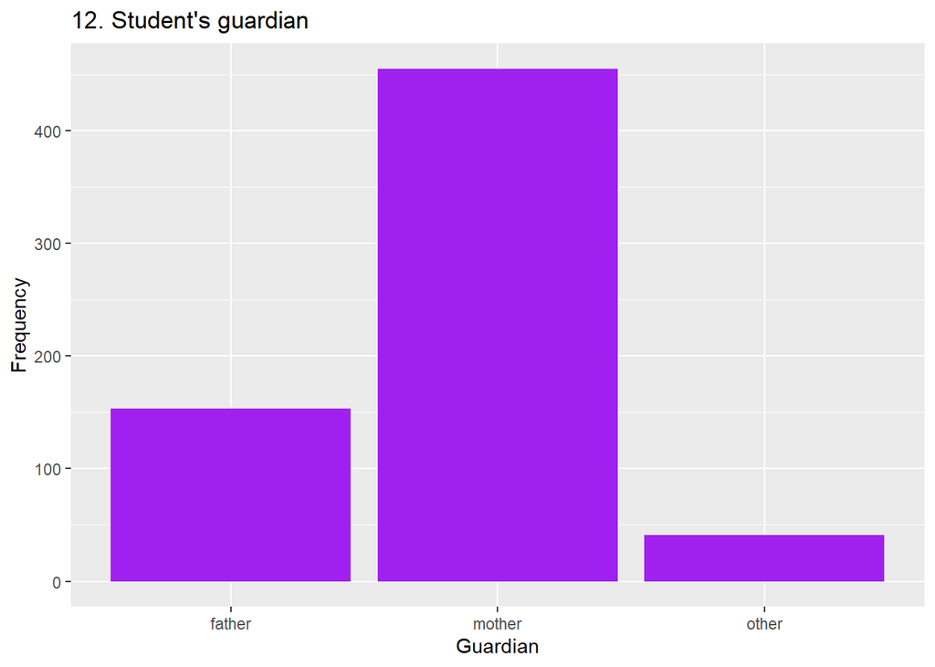

```r
ggplot(df, aes(x = guardian)) +
  geom_bar(fill = "purple") +
  labs(
    x = "Guardian",
    y = "Frequency",
    title = "12. Student's guardian"
  )
```

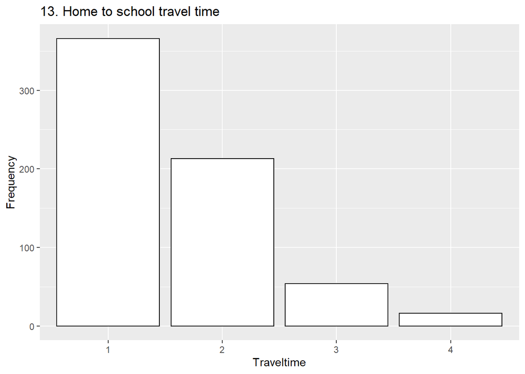

```r
ggplot(df, aes(x = traveltime)) +
  geom_bar(
    fill = "white",
    color = "black"
  ) +
  labs(
    x = "Traveltime",
    y = "Frequency",
    title = "13. Home to school travel time"
  )
```

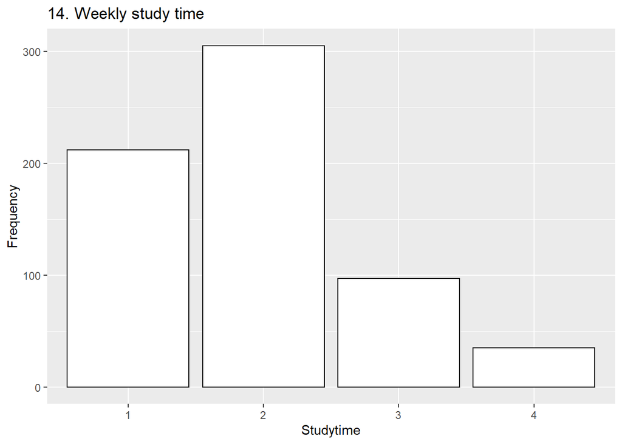

```r
ggplot(df, aes(x = studytime)) +
  geom_bar(
    fill = "white",
    color = "black"
  ) +
  labs(
    x = "Studytime",
    y = "Frequency",
    title = "14. Weekly study time"
  )
```

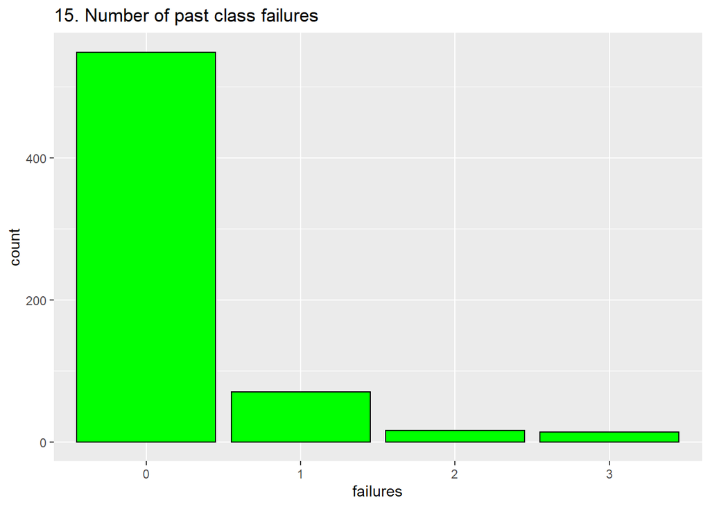

```r
ggplot(df, aes(x = failures)) +
  geom_bar(
    fill = "green",
    color = "black"
  ) +
  labs(title = "15. Number of past class failures")
```

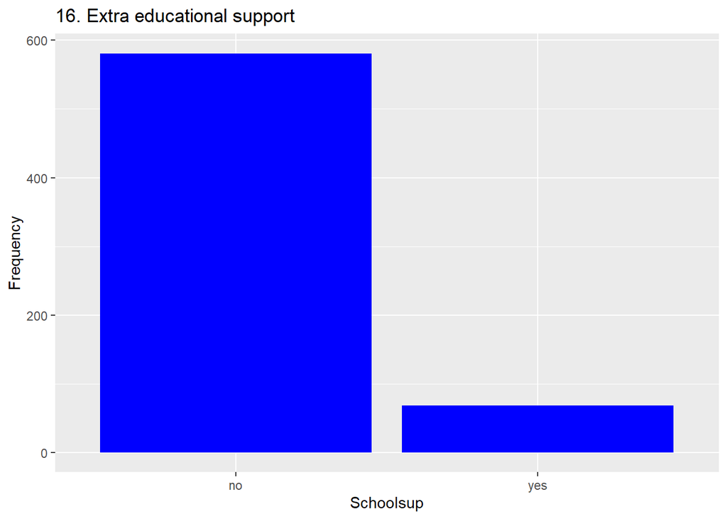

```r
ggplot(df, aes(x = schoolsup)) +
  geom_bar(fill = "blue") +
  labs(
    x = "Schoolsup",
    y = "Frequency",
    title = "16. Extra educational support"
  )
```

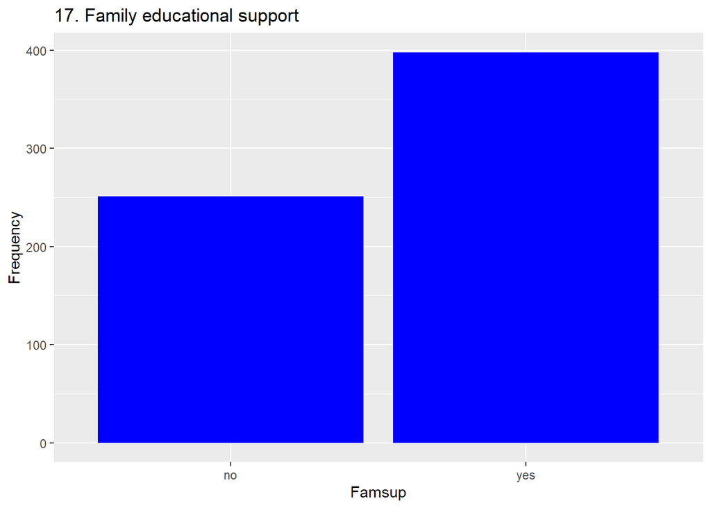

```r
ggplot(df, aes(x = famsup)) +
  geom_bar(fill = "blue") +
  labs(
    x = "Famsup",
    y = "Frequency",
    title = "17. Family educational support"
  )
```

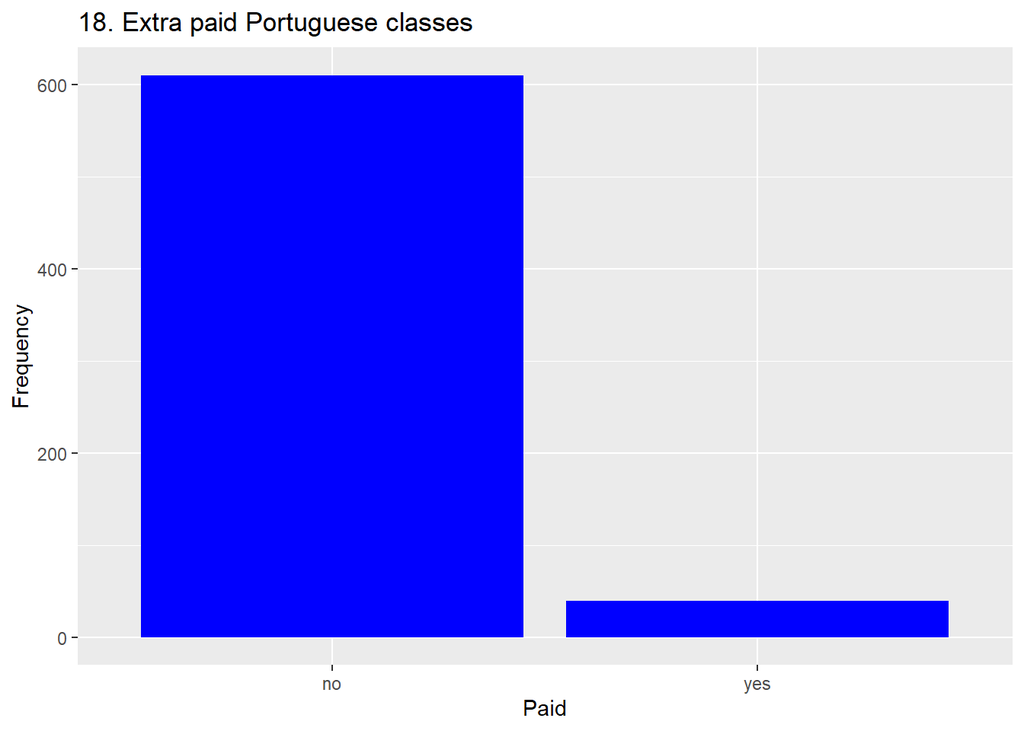

```r
ggplot(df, aes(x = paid)) +
  geom_bar(fill = "blue") +
  labs(
    x = "Paid",
    y = "Frequency",
    title = "18. Extra paid Portuguese classes "
  )
```

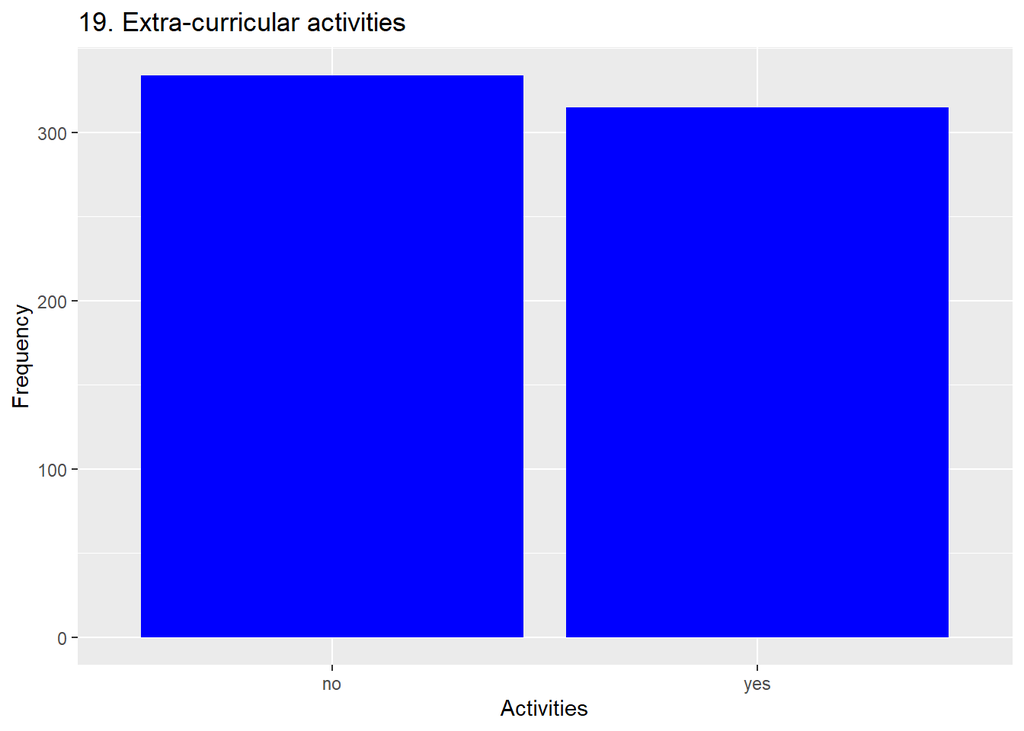

```r
ggplot(df, aes(x = activities)) +
  geom_bar(fill = "blue") +
  labs(
    x = "Activities",
    y = "Frequency",
    title = "19. Extra-curricular activities"
  )
```

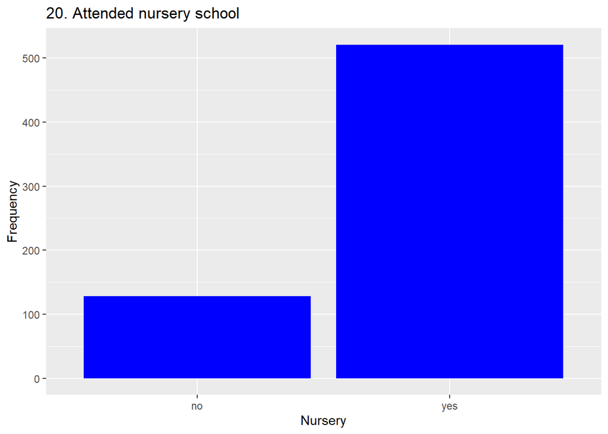

```r
ggplot(df, aes(x = nursery)) +
  geom_bar(fill = "blue") +
  labs(
    x = "Nursery",
    y = "Frequency",
    title = "20. Attended nursery school"
  )
```

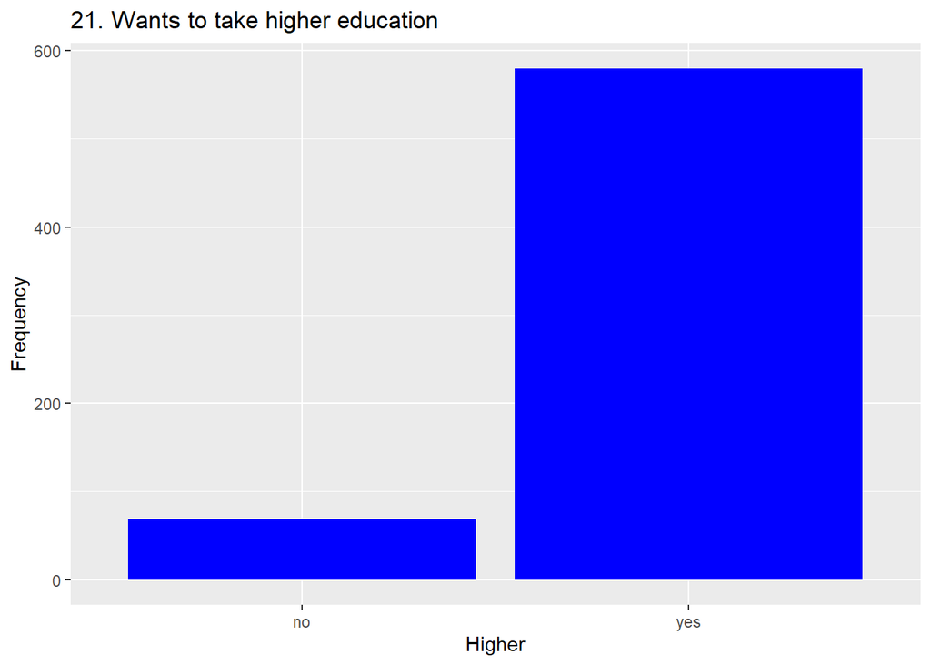

```r
ggplot(df, aes(x = higher)) +
  geom_bar(fill = "blue") +
  labs(
    x = "Higher",
    y = "Frequency",
    title = "21. Wants to take higher education"
  )
```

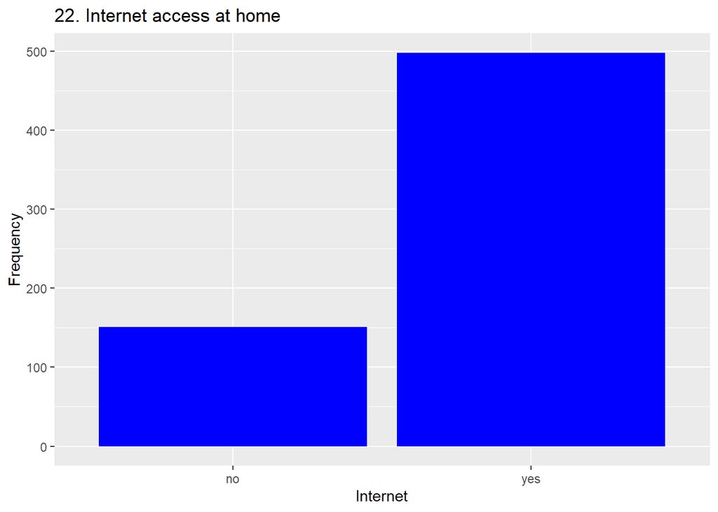

```r
ggplot(df, aes(x = internet)) +
  geom_bar(fill = "blue") +
  labs(
    x = "Internet",
    y = "Frequency",
    title = "22. Internet access at home"
  )
```

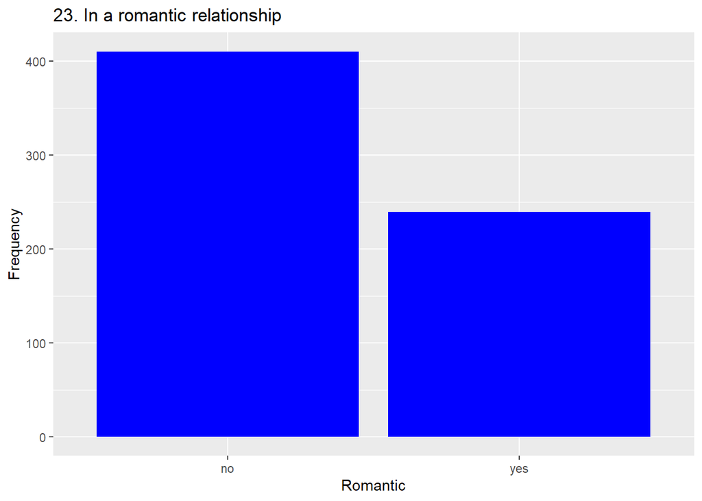

```r
ggplot(df, aes(x = romantic)) +
  geom_bar(fill = "blue") +
  labs(
    x = "Romantic",
    y = "Frequency",
    title = "23. In a romantic relationship"
  )
```

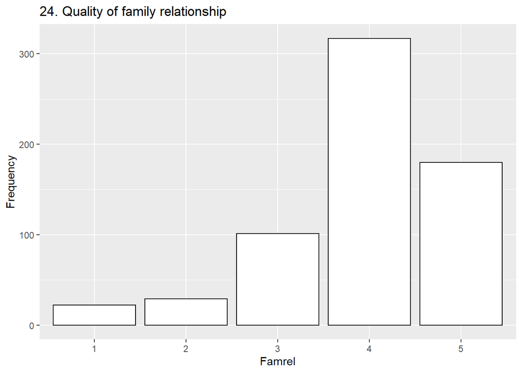

```r
ggplot(df, aes(x = famrel)) +
  geom_bar(
    fill = "white",
    color = "black"
  ) +
  labs(
    x = "Famrel",
    y = "Frequency",
    title = "24. Quality of family relationship"
  )
```

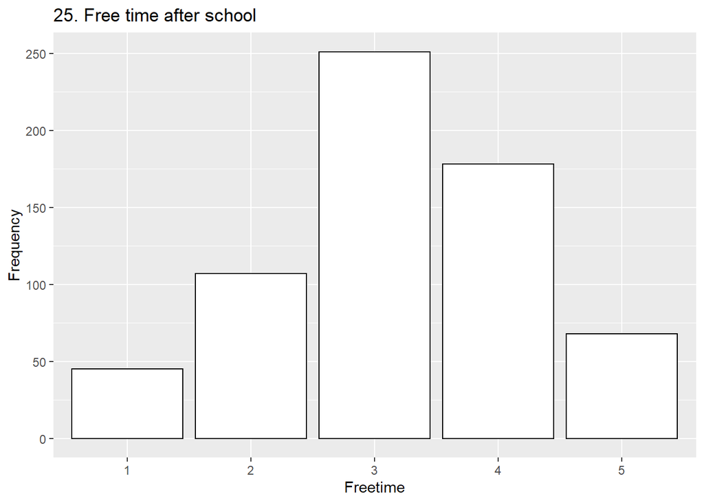

```r
ggplot(df, aes(x = freetime)) +
  geom_bar(
    fill = "white",
    color = "black"
  ) +
  labs(
    x = "Freetime",
    y = "Frequency",
    title = "25. Free time after school"
  )
```

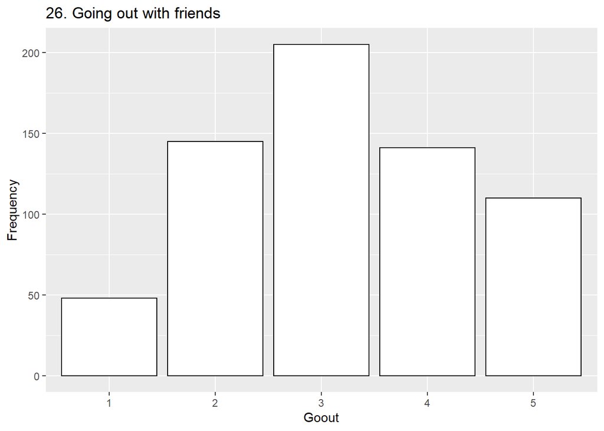

```r
ggplot(df, aes(x = goout)) +
  geom_bar(
    fill = "white",
    color = "black"
  ) +
  labs(
    x = "Goout",
    y = "Frequency",
    title = "26. Going out with friends"
  )
```

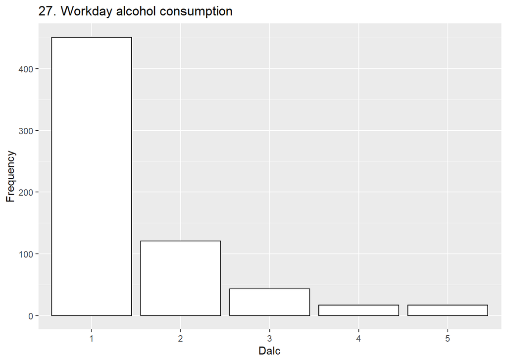

```r
ggplot(df, aes(x = Dalc)) +
  geom_bar(
    fill = "white",
    color = "black"
  ) +
  labs(
    x = "Dalc",
    y = "Frequency",
    title = "27. Workday alcohol consumption"
  )
```

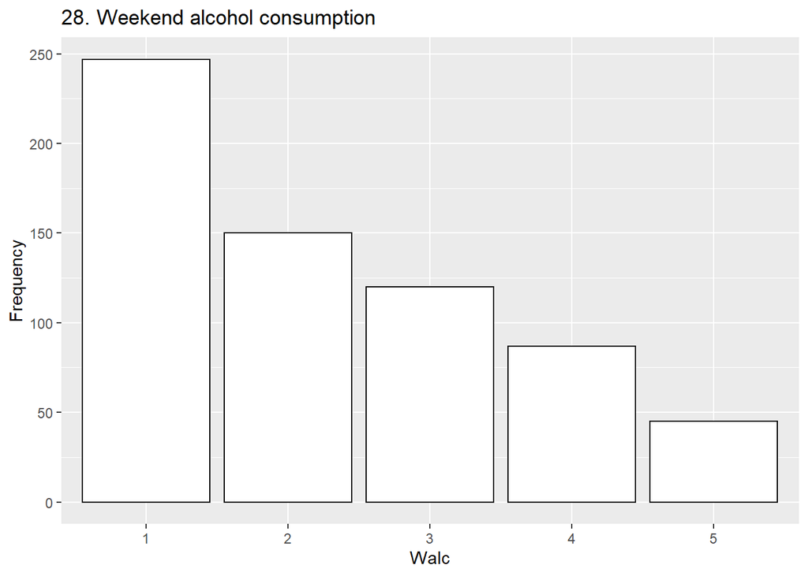

```r
ggplot(df, aes(x = Walc)) +
  geom_bar(
    fill = "white",
    color = "black"
  ) +
  labs(
    x = "Walc",
    y = "Frequency",
    title = "28. Weekend alcohol consumption"
  )
```

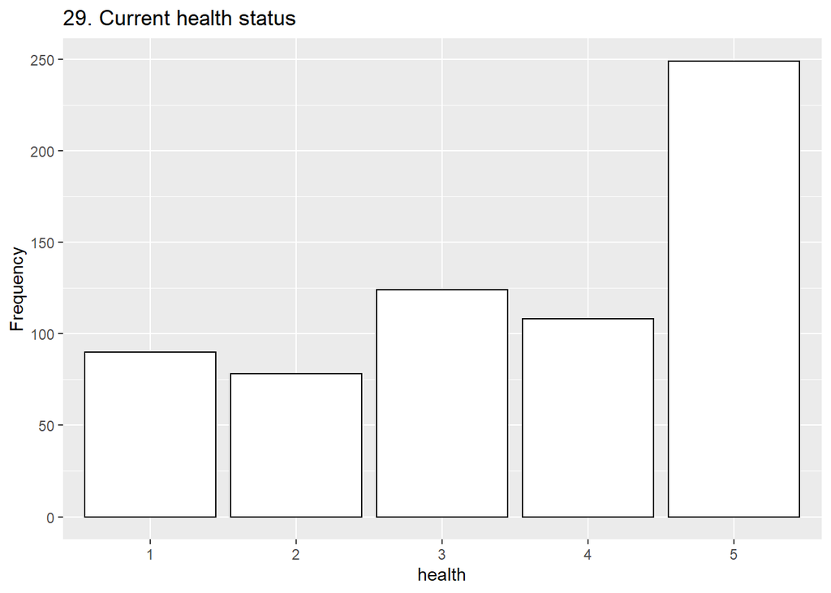

```r
ggplot(df, aes(x = health)) +
  geom_bar(
    fill = "white",
    color = "black"
  ) +
  labs(
    x = "health",
    y = "Frequency",
    title = "29. Current health status"
  )
```

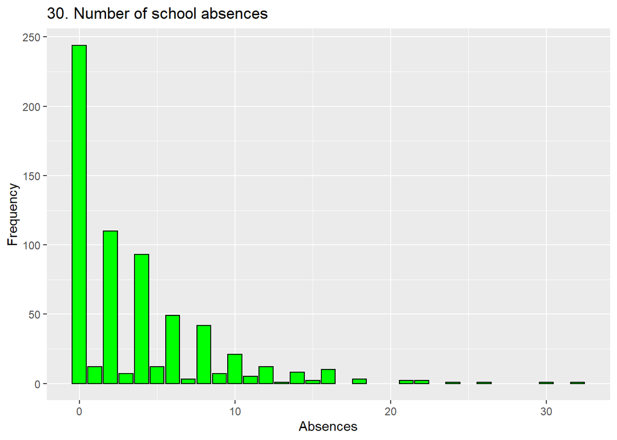

```r
ggplot(df, aes(x = absences)) +
  geom_bar(
    fill = "green",
    color = "black"
  ) +
  labs(
    x = "Absences",
    y = "Frequency",
    title = "30. Number of school absences"
  )
```